# Reproducible Research: Peer Assessment 1

## Loading and preprocessing the data

Load the libraries and load data.

```r
library(dplyr)
library(lubridate)
activity_ori <- read.csv("activity.csv", stringsAsFactors = FALSE)
activity <- tbl_df(activity_ori)
activity <- mutate(activity, date = ymd(date))
```

## What is mean total number of steps taken per day?

Histagram of the steps:

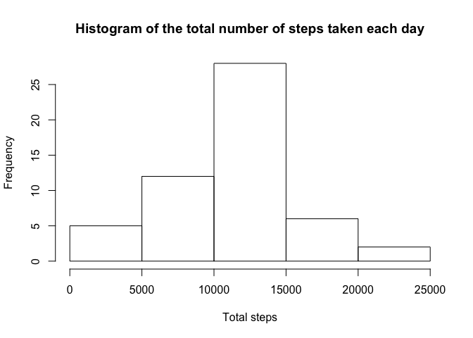

```r
activity_per_day <- group_by(activity, date)
activity_per_day <- summarise(activity_per_day, TotalStep=sum(steps, NA.rm=TRUE))
hist(activity_per_day$TotalStep, main="Histogram of the total number of steps taken each day", xlab="Total steps")
```

Mean of the steps is:

```r
mean(activity_per_day$TotalStep, na.rm = TRUE)
```

```
## [1] 10767.19
```

Median of the steps is:

```r
median(activity_per_day$TotalStep, na.rm = TRUE)
```

```
## [1] 10766
```

## What is the average daily activity pattern?

Get average daily activity pattern by grouping the data by interval. And calculate the mean by the groups.

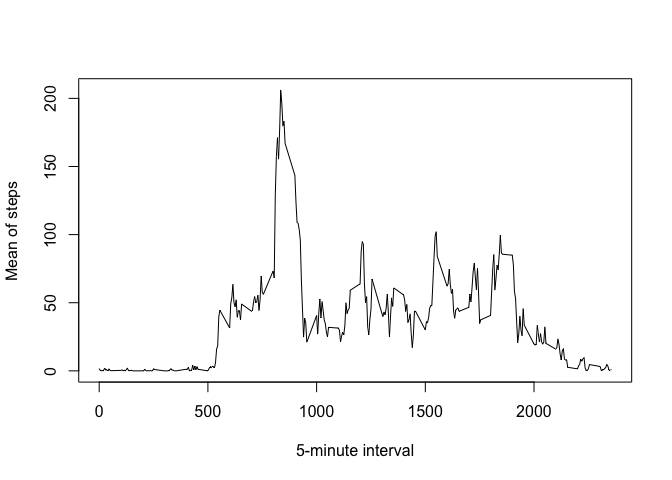

```r
activity_int <- group_by(activity, interval)
y <- summarise(activity_int, value = mean(steps, na.rm = TRUE))
plot(y, type = 'l', ylab = "Mean of steps", xlab = "5-minute interval")
```

Get the interval whcih contains max average steps

```r
maxStepsIndex <- which(y$value == max(y$value))
y$interval[maxStepsIndex]
```

```
## [1] 835
```

## Imputing missing values

The number of missing values are:

```r
sum(is.na(activity))
```

```
## [1] 2304
```

Fill in the missing steps data with mean value of that interval. For all missing value, fillin mean value of that interval of all days (which is alrady got in previous step).

```r
## get data contain NA
activity_fill <- activity_ori
size <- dim(activity)[1]
for (i in 1: size) {
  if (is.na(activity_fill[i, 1])) {
    # get the interval of this NA value.
    currNAInterval <- activity_fill[i, 3]
    # get the mean value of this interval from 'y', which is mean of all days in that interval.
    currMeanVal <- y$value[ y$interval == currNAInterval]
    activity_fill[i, 1] <- currMeanVal
  }
}
```

Then plot the histogram of the total number of steps taken each day. We will group the data by date, can calculate the sum steps of all days.

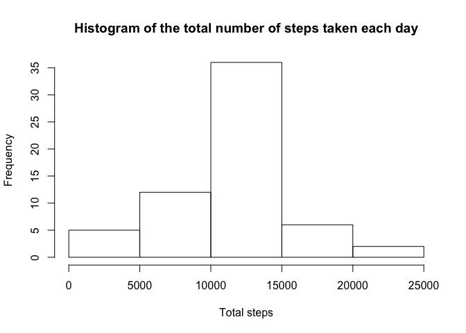

```r
activity_fill_date <- group_by(activity_fill, date)
total_steps_date <- summarise(activity_fill_date, total_steps = sum(steps))
hist(total_steps_date$total_steps, main="Histogram of the total number of steps taken each day", xlab="Total steps")
```

The mean of the total number of steps taken each day:

```r
mean(total_steps_date$total_steps)
```

```
## [1] 10766.19
```

The median of the total number of steps taken each day:

```r
median(total_steps_date$total_steps)
```

```
## [1] 10766.19
```

## Are there differences in activity patterns between weekdays and weekends?

Add weekday or weekend factor into data, and geoup by interval and weekday type.

```r
activity_week <- mutate(activity, ww = weekdays(date), ww = (ww == "Sunday" | ww =="Saturday"), ww = ifelse(ww, "weekend", "weekday"), ww = as.factor(ww))
activity_week_int <- group_by(activity_week, interval, ww)
weekdata_summ <- summarise(activity_week_int, steps_sum = mean(steps, na.rm = TRUE))
```

Then plot the data by weekday or weekend:

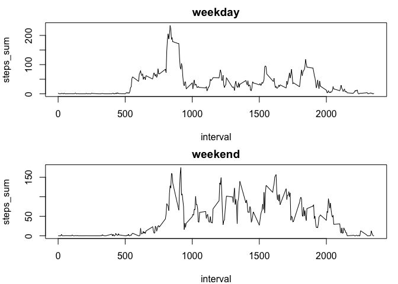

```r
par(mfrow = c(2,1), mar = c(4,4,2,1))
plot(weekdata_summ[weekdata_summ$ww == "weekday", c(1,3)], type = 'l', main = "weekday")
plot(weekdata_summ[weekdata_summ$ww == "weekend", c(1,3)], type = 'l', main = "weekend")
```